# Lessons L1

## Introduction

For our practical R course building-up skills for analyzing movement data in the software environment R, you’ll be using data from the ZHAW project “Wildtier und Mensch im Naherholungsraum”1. The project investigates the interaction and disturbance dynamics between animals living in habitats that are also used by humans as recreational areas. We’ll study trajectories of *roe deer* (dt. *Reh*) and mountain bikers, practicing the most basic analysis tasks of Computational Movement Analysis (CMA).

Lesson L1 covers the necessary steps for getting ready in R and some basic concepts for setting up a well-structured R project. The lesson introduces how additional packages that provide useful functions are made available and how temporal data is handled. The lesson concludes with the creation of your first map featuring movement data.

**Please note** we are given this data under the condition of signing a non-disclosure agreement. Why? This is data coming out of an ongoing research project. Capturing wild living animals and then equipping them with GPS collars is a very labor and cost intensive form of research. Consequently, data resulting such campaigns is a very valuable asset that must be protected.

## Leaning outcomes

- You learn how to structure an R project.
- You can read movement data from a .csv-file into a data.frame and into a move object.
- You can produce simple maps of your trajectory data using ggplot2 and leaflet

## Tasks

### Task 1: Prepare project

Create a new RStudio Project. Create a new R-File and divide it into the sections neccessary in a classical Data Science Workflow. “Sections” are created within RStudio by adding Comments (#) with at least 4 Trailing dashes (-), equal signs (=), or pound signs (#) (see below). Sections allow code folding (click on the small triangle next to the line number) and provides and navigation (type Shift+Alt+J).

```r
# Loading enironment / libraries ####

# Data import ####

# Data clensing ####

# Data analysis and visualization ####
```

```r
# Loading enironment / libraries ####

# install.packages("tidyverse")
library(tidyverse)
```

In the first section (loading environment / libraries), add the code to install and load the package “tidyverse”. Once you’ve installed the package, you can uncomment the corresponding line of code, because you will not need to execute this line in your next R Session.

### Task 2: Import data

In section “data import”, import the files `Roe_gps_all.csv` and `Roe_meta.csv`.

Tipp: RStudio provides [a graphical tool](https://support.rstudio.com/hc/en-us/articles/218611977-Importing-Data-with-RStudio) which you can use to build your `read_csv()` command. However, in regard to the reproducibility of your script, you will need to copy the “import” statement into your script (in the section “data import”). This will ensure that your worflow is documented without gaps.

```r
# Data import ####
roe_gps_all <-read_csv("20_Rawdata/Roe_gps_all.csv")
```

### Task 3: Clean data

In section “Data clensing”, drop the columns we do not need at the moment. Since we’re not actually deleting any columns withint the original data, you can drop columns generously. For the moment, we only need columns “TierID”, “LMT_Date”, “LMT_Time”, “DOP”, “Latitude….” and “Longitude….”. Remove the “….” from the column name. Do not touch the original data to do this, change the name within R.

```r
# Data clensing ####

roe_gps_all <- select(roe_gps_all,"TierID","LMT_Date","LMT_Time","DOP","Latitude....","Longitude....")

roe_gps_all <- rename(roe_gps_all,Lat = Latitude....)
roe_gps_all <- rename(roe_gps_all,Lng = Longitude....)
```

### Task 3

Make a first “map-like” plot of your data producing a simple scatter plot with ggplot2. Assign every individual animal its own colour (using the ggplot2 argument colour). Do you spot outliers? If so, get rid of the outliers. Plot your data again, this time without outliers. Save your plot using ggsave(). Save your code in the listing 1.4_plotting_ggplot.R. Setting up a ggplot with our data is done using the command ggplot(roe_gps_all, aes(X, Y, colour = TierID)). Creating a map is done via the basic scatter plot command geom_point(), using a fixed aspect ratio of 1.

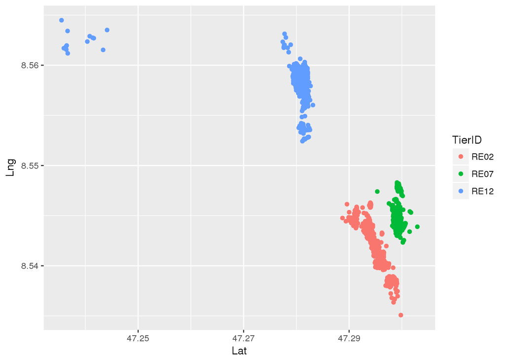

```r
ggplot(roe_gps_all, aes(Lat,Lng, colour = TierID)) +
  geom_point()
```

### Task 4

Now we want to produce a nicer map with an OpenStreetMap basemap. This can be done with leaflet First, you load the library within your “Loading enironment / libraries” section

```r
# Loading enironment / libraries ####
library(tidyverse)
library(leaflet)
```

Then, create a leaflet object with leaflet() and subsequently add the neccessary layers. Our Layers at the moment are simply a point (circle) representation of the positions and a background basemap:

```r
map <- leaflet(roe_gps_all)
map <- addCircles(map, lat = ~Lat, lng = ~Lng)

map <- addTiles(map)

map
```

[interactive chart not shown]